# Part05

# 5. 데이터 분석 기초!

## 데이터 파악하기, 다루기 쉽게 수정하기

[figure not shown]

## 05-1. 데이터 파악하기

| 함수 | 기능 |
| --- | --- |
| head() | 데이터 앞부분 출력 |
| tail() | 데이터 뒷부분 출력 |
| View() | 뷰어 창에서 데이터 확인 |
| dim() | 데이터 차원 출력 |
| str() | 데이터 속성 출력 |
| summary() | 요약통계량 출력 |

### exam 데이터 파악하기

#### 데이준 준비

```r
exam <- read.csv("data/csv_exam.csv")
```

#### head() - 데이터 앞부분 확인하기

```r
head(exam)      # 앞에서부터 6행까지 출력
```

|  | id | class | math | english | science |
| --- | --- | --- | --- | --- | --- |
| 1 | 1 | 1 | 50 | 98 | 50 |
| 2 | 2 | 1 | 60 | 97 | 60 |
| 3 | 3 | 1 | 45 | 86 | 78 |
| 4 | 4 | 1 | 30 | 98 | 58 |
| 5 | 5 | 2 | 25 | 80 | 65 |
| 6 | 6 | 2 | 50 | 89 | 98 |

```r
head(exam, 10)  # 앞에서부터 10행까지 출력
```

|  | id | class | math | english | science |
| --- | --- | --- | --- | --- | --- |
| 1 | 1 | 1 | 50 | 98 | 50 |
| 2 | 2 | 1 | 60 | 97 | 60 |
| 3 | 3 | 1 | 45 | 86 | 78 |
| 4 | 4 | 1 | 30 | 98 | 58 |
| 5 | 5 | 2 | 25 | 80 | 65 |
| 6 | 6 | 2 | 50 | 89 | 98 |
| 7 | 7 | 2 | 80 | 90 | 45 |
| 8 | 8 | 2 | 90 | 78 | 25 |
| 9 | 9 | 3 | 20 | 98 | 15 |
| 10 | 10 | 3 | 50 | 98 | 45 |

#### tail() - 데이터 뒷부분 확인하기

```r
tail(exam)      # 뒤에서부터 6행까지 출력
```

|  | id | class | math | english | science |
| --- | --- | --- | --- | --- | --- |
| 15 | 15 | 4 | 75 | 56 | 78 |
| 16 | 16 | 4 | 58 | 98 | 65 |
| 17 | 17 | 5 | 65 | 68 | 98 |
| 18 | 18 | 5 | 80 | 78 | 90 |
| 19 | 19 | 5 | 89 | 68 | 87 |
| 20 | 20 | 5 | 78 | 83 | 58 |

```r
tail(exam, 10)  # 뒤에서부터 10행까지 출력
```

|  | id | class | math | english | science |
| --- | --- | --- | --- | --- | --- |
| 11 | 11 | 3 | 65 | 65 | 65 |
| 12 | 12 | 3 | 45 | 85 | 32 |
| 13 | 13 | 4 | 46 | 98 | 65 |
| 14 | 14 | 4 | 48 | 87 | 12 |
| 15 | 15 | 4 | 75 | 56 | 78 |
| 16 | 16 | 4 | 58 | 98 | 65 |
| 17 | 17 | 5 | 65 | 68 | 98 |
| 18 | 18 | 5 | 80 | 78 | 90 |
| 19 | 19 | 5 | 89 | 68 | 87 |
| 20 | 20 | 5 | 78 | 83 | 58 |

#### View() - 뷰어 창에서 데이터 확인하기

```r
View(exam)
```

> [유의] View()에서 맨 앞의 V는 대문자

#### dim() - 몇 행 몇 열로 구성되는지 알아보기

```r
dim(exam)  # 행, 열 출력
```

```
[1] 20  5
```

#### str() - 속성 파악하기

```r
str(exam)  # 데이터 속성 확인
```

```
'data.frame':   20 obs. of  5 variables:
 $ id     : int  1 2 3 4 5 6 7 8 9 10 ...
 $ class  : int  1 1 1 1 2 2 2 2 3 3 ...
 $ math   : int  50 60 45 30 25 50 80 90 20 50 ...
 $ english: int  98 97 86 98 80 89 90 78 98 98 ...
 $ science: int  50 60 78 58 65 98 45 25 15 45 ...
```

#### summary() - 기초통계량 산출하기

```r
summary(exam)  # 요약통계량 출력
```

```
       id            class        math          english        science
 Min.   : 1.00   Min.   :1   Min.   :20.00   Min.   :56.0   Min.   :12.00
 1st Qu.: 5.75   1st Qu.:2   1st Qu.:45.75   1st Qu.:78.0   1st Qu.:45.00
 Median :10.50   Median :3   Median :54.00   Median :86.5   Median :62.50
 Mean   :10.50   Mean   :3   Mean   :57.45   Mean   :84.9   Mean   :59.45
 3rd Qu.:15.25   3rd Qu.:4   3rd Qu.:75.75   3rd Qu.:98.0   3rd Qu.:78.00
 Max.   :20.00   Max.   :5   Max.   :90.00   Max.   :98.0   Max.   :98.00
```

### mpg 데이터 파악하기

```r
# ggplo2의 mpg 데이터를 데이터 프레임 형태로 불러오기
mpg <- as.data.frame(ggplot2::mpg)
```

### mpg 데이터 파악하기

```r
head(mpg)    # Raw 데이터 앞부분 확인
```

|  | manufacturer | model | displ | year | cyl | trans | drv | cty | hwy | fl | class |
| --- | --- | --- | --- | --- | --- | --- | --- | --- | --- | --- | --- |
| 1 | audi | a4 | 1.8 | 1999 | 4 | auto(l5) | f | 18 | 29 | p | compact |
| 2 | audi | a4 | 1.8 | 1999 | 4 | manual(m5) | f | 21 | 29 | p | compact |
| 3 | audi | a4 | 2.0 | 2008 | 4 | manual(m6) | f | 20 | 31 | p | compact |
| 4 | audi | a4 | 2.0 | 2008 | 4 | auto(av) | f | 21 | 30 | p | compact |
| 5 | audi | a4 | 2.8 | 1999 | 6 | auto(l5) | f | 16 | 26 | p | compact |
| 6 | audi | a4 | 2.8 | 1999 | 6 | manual(m5) | f | 18 | 26 | p | compact |

```r
tail(mpg)    # Raw 데이터 뒷부분 확인
```

|  | manufacturer | model | displ | year | cyl | trans | drv | cty | hwy | fl | class |
| --- | --- | --- | --- | --- | --- | --- | --- | --- | --- | --- | --- |
| 229 | volkswagen | passat | 1.8 | 1999 | 4 | auto(l5) | f | 18 | 29 | p | midsize |
| 230 | volkswagen | passat | 2.0 | 2008 | 4 | auto(s6) | f | 19 | 28 | p | midsize |
| 231 | volkswagen | passat | 2.0 | 2008 | 4 | manual(m6) | f | 21 | 29 | p | midsize |
| 232 | volkswagen | passat | 2.8 | 1999 | 6 | auto(l5) | f | 16 | 26 | p | midsize |
| 233 | volkswagen | passat | 2.8 | 1999 | 6 | manual(m5) | f | 18 | 26 | p | midsize |
| 234 | volkswagen | passat | 3.6 | 2008 | 6 | auto(s6) | f | 17 | 26 | p | midsize |

```r
View(mpg)    # Raw 데이터 뷰어 창 확인
```

```r
dim(mpg)     # 행, 열 출력
```

```
[1] 234  11
```

```r
str(mpg)     # 데이터 속성 확인
```

```
'data.frame':   234 obs. of  11 variables:
 $ manufacturer: chr  "audi" "audi" "audi" "audi" ...
 $ model       : chr  "a4" "a4" "a4" "a4" ...
 $ displ       : num  1.8 1.8 2 2 2.8 2.8 3.1 1.8 1.8 2 ...
 $ year        : int  1999 1999 2008 2008 1999 1999 2008 1999 1999 2008 ...
 $ cyl         : int  4 4 4 4 6 6 6 4 4 4 ...
 $ trans       : chr  "auto(l5)" "manual(m5)" "manual(m6)" "auto(av)" ...
 $ drv         : chr  "f" "f" "f" "f" ...
 $ cty         : int  18 21 20 21 16 18 18 18 16 20 ...
 $ hwy         : int  29 29 31 30 26 26 27 26 25 28 ...
 $ fl          : chr  "p" "p" "p" "p" ...
 $ class       : chr  "compact" "compact" "compact" "compact" ...
```

```r
summary(mpg)  # 기초통계량 출력
```

```
 manufacturer          model               displ            year
 Length:234         Length:234         Min.   :1.600   Min.   :1999
 Class :character   Class :character   1st Qu.:2.400   1st Qu.:1999
 Mode  :character   Mode  :character   Median :3.300   Median :2004
                                       Mean   :3.472   Mean   :2004
                                       3rd Qu.:4.600   3rd Qu.:2008
                                       Max.   :7.000   Max.   :2008
      cyl           trans               drv                 cty
 Min.   :4.000   Length:234         Length:234         Min.   : 9.00
 1st Qu.:4.000   Class :character   Class :character   1st Qu.:14.00
 Median :6.000   Mode  :character   Mode  :character   Median :17.00
 Mean   :5.889                                         Mean   :16.86
 3rd Qu.:8.000                                         3rd Qu.:19.00
 Max.   :8.000                                         Max.   :35.00
      hwy             fl               class
 Min.   :12.00   Length:234         Length:234
 1st Qu.:18.00   Class :character   Class :character
 Median :24.00   Mode  :character   Mode  :character
 Mean   :23.44
 3rd Qu.:27.00
 Max.   :44.00
```

## 2. 데이터 수정하기 - 변수명 바꾸기

#### dplyr 패키지 설치 & 로드

```r
install.packages("dplyr")  # dplyr 설치
library(dplyr)             # dplyr 로드
```

#### 데이터 프레임 생성

```r
df_raw <- data.frame(var1=c(1, 2, 1),
                     var2=c(2, 3, 2))
df_raw
```

| var1 | var2 |
| --- | --- |
| 1 | 2 |
| 2 | 3 |
| 1 | 2 |

#### 1. 데이터 프레임 복사본 만들기

```r
df_new <- df_raw  # 복사본 생성
df_new            # 출력
```

| var1 | var2 |
| --- | --- |
| 1 | 2 |
| 2 | 3 |
| 1 | 2 |

#### 2. 변수명 바꾸기 - `rename()`

```r
df_new <- rename(df_new, v2=var2)  # var2를 v2로 수정
df_new
```

| var1 | v2 |
| --- | --- |
| 1 | 2 |
| 2 | 3 |
| 1 | 2 |

> [유의] rename()에 ‘새 변수명 = 기존 변수명’ 순서로 입력

#### 수정 전후 비교

```r
df_raw
```

| var1 | var2 |
| --- | --- |
| 1 | 2 |
| 2 | 3 |
| 1 | 2 |

```r
df_new
```

| var1 | v2 |
| --- | --- |
| 1 | 2 |
| 2 | 3 |
| 1 | 2 |

### 혼자서 해보기

`mpg` 데이터의 변수명은 긴 단어를 짧게 줄인 축약어로 되어있습니다. `cty` 변수는 도시 연비, `hwy` 변수는 고속도로 연비를 의미합니다. 변수명을 이해하기 쉬운 단어로 바꾸려고 합니다. `mpg` 데이터를 이용해서 아래 문제를 해결해 보세요.

- Q1. `ggplot2` 패키지의 `mpg` 데이터를 사용할 수 있도록 불러온 뒤 복사본을 만드세요.
- Q2. 복사본 데이터를 이용해서 `cty`는 `city`로, `hwy`는 `highway`로 변수명을 수정하세요.
- Q3. 데이터 일부를 출력해서 변수명이 바뀌었는지 확인해 보세요. 아래와 같은 결과물이 출력되어야 합니다.

|  | manufacturer | model | displ | year | cyl | trans | drv | city | highway | fl | class |
| --- | --- | --- | --- | --- | --- | --- | --- | --- | --- | --- | --- |
| 1 | audi | a4 | 1.8 | 1999 | 4 | auto(l5) | f | 18 | 29 | p | compact |
| 2 | audi | a4 | 1.8 | 1999 | 4 | manual(m5) | f | 21 | 29 | p | compact |
| 3 | audi | a4 | 2.0 | 2008 | 4 | manual(m6) | f | 20 | 31 | p | compact |
| 4 | audi | a4 | 2.0 | 2008 | 4 | auto(av) | f | 21 | 30 | p | compact |
| 5 | audi | a4 | 2.8 | 1999 | 6 | auto(l5) | f | 16 | 26 | p | compact |
| 6 | audi | a4 | 2.8 | 1999 | 6 | manual(m5) | f | 18 | 26 | p | compact |

### 정답

Q2. 복사본 데이터를 이용해서 `cty`는 `city`로, `hwy`는 `highway`로 변수명을 수정하세요.

```r
mpg_new <- rename(mpg_new, city=cty)     # cty를 city로 수정
mpg_new <- rename(mpg_new, highway=hwy)  # hwy를 highway로 수정
```

Q3. 데이터 일부를 출력해서 변수명이 바뀌었는지 확인해 보세요. 아래와 같은 결과물이 출력되어야 합니다.

```r
head(mpg_new)                              # 데이터 일부 출력
```

|  | manufacturer | model | displ | year | cyl | trans | drv | city | highway | fl | class |
| --- | --- | --- | --- | --- | --- | --- | --- | --- | --- | --- | --- |
| 1 | audi | a4 | 1.8 | 1999 | 4 | auto(l5) | f | 18 | 29 | p | compact |
| 2 | audi | a4 | 1.8 | 1999 | 4 | manual(m5) | f | 21 | 29 | p | compact |
| 3 | audi | a4 | 2.0 | 2008 | 4 | manual(m6) | f | 20 | 31 | p | compact |
| 4 | audi | a4 | 2.0 | 2008 | 4 | auto(av) | f | 21 | 30 | p | compact |
| 5 | audi | a4 | 2.8 | 1999 | 6 | auto(l5) | f | 16 | 26 | p | compact |
| 6 | audi | a4 | 2.8 | 1999 | 6 | manual(m5) | f | 18 | 26 | p | compact |

## 05-3. 파생변수 만들기

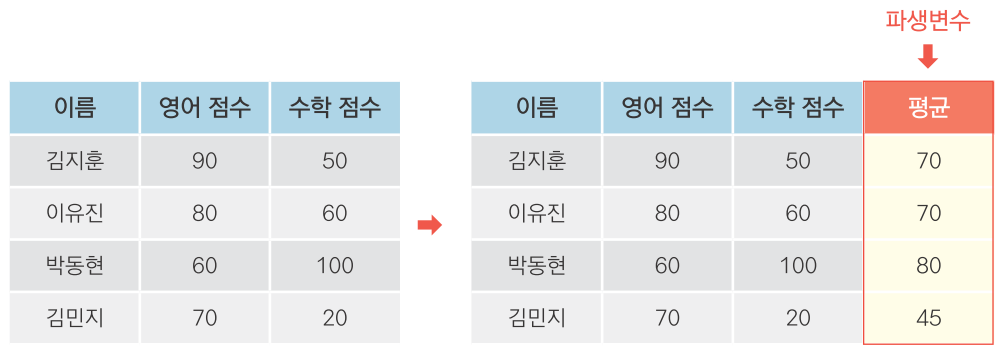

### 변수 조합해 파생변수 만들기

#### 데이터 프레임 생성

```r
df <- data.frame(var1=c(4, 3, 8),
                 var2=c(2, 6, 1))
df
```

| var1 | var2 |
| --- | --- |
| 4 | 2 |
| 3 | 6 |
| 8 | 1 |

#### 파생변수 생성

```r
df$var_sum <- df$var1 + df$var2  # var_sum 파생변수 생성
df
```

| var1 | var2 | var_sum |
| --- | --- | --- |
| 4 | 2 | 6 |
| 3 | 6 | 9 |
| 8 | 1 | 9 |

#### 파생변수 생성

```r
df$var_mean <- (df$var1 + df$var2)/2  # var_mean 파생변수 생성
df
```

| var1 | var2 | var_sum | var_mean |
| --- | --- | --- | --- |
| 4 | 2 | 6 | 3.0 |
| 3 | 6 | 9 | 4.5 |
| 8 | 1 | 9 | 4.5 |

### mpg 통합 연비 변수 만들기

```r
mpg$total <- (mpg$cty + mpg$hwy)/2  # 통합 연비 변수 생성
head(mpg)
```

|  | manufacturer | model | displ | year | cyl | trans | drv | cty | hwy | fl | class | total |
| --- | --- | --- | --- | --- | --- | --- | --- | --- | --- | --- | --- | --- |
| 1 | audi | a4 | 1.8 | 1999 | 4 | auto(l5) | f | 18 | 29 | p | compact | 23.5 |
| 2 | audi | a4 | 1.8 | 1999 | 4 | manual(m5) | f | 21 | 29 | p | compact | 25.0 |
| 3 | audi | a4 | 2.0 | 2008 | 4 | manual(m6) | f | 20 | 31 | p | compact | 25.5 |
| 4 | audi | a4 | 2.0 | 2008 | 4 | auto(av) | f | 21 | 30 | p | compact | 25.5 |
| 5 | audi | a4 | 2.8 | 1999 | 6 | auto(l5) | f | 16 | 26 | p | compact | 21.0 |
| 6 | audi | a4 | 2.8 | 1999 | 6 | manual(m5) | f | 18 | 26 | p | compact | 22.0 |

```r
mean(mpg$total)
```

```
[1] 20.14957
```

### 조건문을 활용해 파생변수 만들기

#### 1.기준값 정하기

```r
summary(mpg$total)  # 기초통계량 산출
```

```
   Min. 1st Qu.  Median    Mean 3rd Qu.    Max.
  10.50   15.50   20.50   20.15   23.50   39.50
```

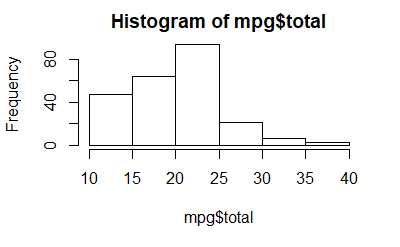

```r
hist(mpg$total)     # 히스토그램 생성
```

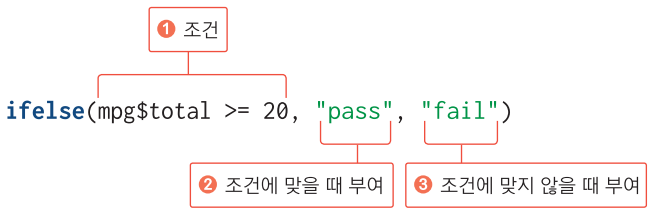

```r
head(mpg, 20) # 데이터 확인
```

|  | manufacturer | model | displ | year | cyl | trans | drv | cty | hwy | fl | class | total | test |
| --- | --- | --- | --- | --- | --- | --- | --- | --- | --- | --- | --- | --- | --- |
| 1 | audi | a4 | 1.8 | 1999 | 4 | auto(l5) | f | 18 | 29 | p | compact | 23.5 | pass |
| 2 | audi | a4 | 1.8 | 1999 | 4 | manual(m5) | f | 21 | 29 | p | compact | 25.0 | pass |
| 3 | audi | a4 | 2.0 | 2008 | 4 | manual(m6) | f | 20 | 31 | p | compact | 25.5 | pass |
| 4 | audi | a4 | 2.0 | 2008 | 4 | auto(av) | f | 21 | 30 | p | compact | 25.5 | pass |
| 5 | audi | a4 | 2.8 | 1999 | 6 | auto(l5) | f | 16 | 26 | p | compact | 21.0 | pass |
| 6 | audi | a4 | 2.8 | 1999 | 6 | manual(m5) | f | 18 | 26 | p | compact | 22.0 | pass |
| 7 | audi | a4 | 3.1 | 2008 | 6 | auto(av) | f | 18 | 27 | p | compact | 22.5 | pass |
| 8 | audi | a4 quattro | 1.8 | 1999 | 4 | manual(m5) | 4 | 18 | 26 | p | compact | 22.0 | pass |
| 9 | audi | a4 quattro | 1.8 | 1999 | 4 | auto(l5) | 4 | 16 | 25 | p | compact | 20.5 | pass |
| 10 | audi | a4 quattro | 2.0 | 2008 | 4 | manual(m6) | 4 | 20 | 28 | p | compact | 24.0 | pass |

[output cut: 10 more lines]

#### 3. 빈도표로 합격 판정 자동차 수 살펴보기

```r
table(mpg$test)  # 연비 합격 빈도표 생성
```

```
fail pass
 106  128
```

#### 4. 막대 그래프빈 빈도 표현하기

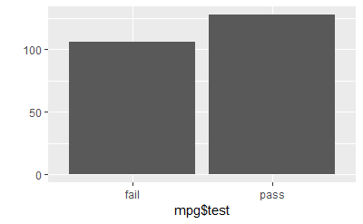

```r
library(ggplot2)  # ggplot2 로드
qplot(mpg$test)   # 연비 합격 빈도 막대 그래프 생성
```

### 중첩 조건문 활용하기 - 연비 등급 변수 만들기

| 등급 | total 기준 |
| --- | --- |
| A | 30 이상 |
| B | 20~29 |
| C | 20 미만 |

[output not shown]

[output cut: 10 more lines]

#### 빈도표, 막대 그래프로 연비 등급 살펴보기

```r
table(mpg$grade) # 등급 빈도표 생성
```

```
  A   B   C
 10 118 106
```

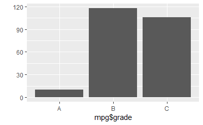

```r
qplot(mpg$grade) # 등급 빈도 막대 그래프 생성
```

### 원하는 만큼 범주 만들기

```r
# A, B, C, D 등급 부여
mpg$grade2 <- ifelse(mpg$total >= 30, "A",
                     ifelse(mpg$total >= 25, "B",
                            ifelse(mpg$total >= 20, "C", "D")))
```

### 정리하기

```r
# 1.데이터 준비, 패키지 준비
mpg <- as.data.frame(ggplot2::mpg)  # 데이터 불러오기
library(dplyr)                      # dplyr 로드
library(ggplot2)                    # ggplot2 로드

# 2.데이터 파악
head(mpg)     # 데이터 앞부분
tail(mpg)     # 데이터 뒷부분
View(mpg)     # 데이터 뷰어창에서 확인
dim(mpg)      # 차원
str(mpg)      # 속성
summary(mpg)  # 기초통계량
```

### 정리하기

```r
# 3.변수명 수정
mpg <- rename(mpg, company=manufacturer)

# 4.파생변수 생성
mpg$total <- (mpg$cty + mpg$hwy)/2                   # 변수 조합
mpg$test <- ifelse(mpg$total >= 20, "pass", "fail")  # 조건문 활용

# 5.빈도 확인
table(mpg$test)  # 빈도표 출력
qplot(mpg$test)  # 막대 그래프 생성
```

## 분석 도전!

`ggplot2` 패키지에는 미국 동북중부 437개 지역의 인구통계 정보를 담은 `midwest`라는 데이터가 포함되어 있습니다. `midwest` 데이터를 사용해 데이터 분석 문제를 해결해보세요.

- 문제1. `ggplot2`의 `midwest` 데이터를 데이터 프레임 형태로 불러와서 데이터의 특성을 파악하세요.
- 문제2. `poptotal`(전체 인구)을 `total`로, `popasian`(아시아 인구)을 `asian`으로 변수명을 수정하세요.
- 문제3. `total`, `asian` 변수를 이용해 ‘전체 인구 대비 아시아 인구 백분율’ 파생변수를 만들고, 히스토그램을 만들어 도시들이 어떻게 분포하는지 살펴보세요.
- 문제4. 아시아 인구 백분율 전체 평균을 구하고, 평균을 초과하면 `"large"`, 그 외에는 `"small"`을 부여하는 파생변수를 만들어 보세요.
- 문제5. `"large"`와 `"small"`에 해당하는 지역이 얼마나 되는지, 빈도표와 빈도 막대 그래프를 만들어 확인해 보세요.

### 분석 도전 정답

문제1. `ggplot2`의 `midwest` 데이터를 데이터 프레임 형태로 불러와서 데이터의 특성을 파악하세요.

```r
midwest <- as.data.frame(ggplot2::midwest)
head(midwest)
tail(midwest)
View(midwest)
dim(midwest)
str(midwest)
summary(midwest)
```

문제2. `poptotal`(전체 인구)을 `total`로, `popasian`(아시아 인구)을 `asian`으로 변수명을 수정하세요.

```r
library(dplyr)
midwest <- rename(midwest, total=poptotal)
midwest <- rename(midwest, asian=popasian)
```

문제3. `total`, `asian` 변수를 이용해 ‘전체 인구 대비 아시아 인구 백분율’ 파생변수를 만들고, 히스토그램을 만들어 도시들이 어떻게 분포하는지 살펴보세요.

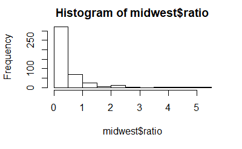

```r
midwest$ratio <- midwest$asian/midwest$total*100
hist(midwest$ratio)
```

문제4. 아시아 인구 백분율 전체 평균을 구하고, 평균을 초과하면 `"large"`, 그 외에는 `"small"`을 부여하는 파생변수를 만들어 보세요.

```r
mean(midwest$ratio)
```

```
[1] 0.4872462
```

```r
midwest$group <- ifelse(midwest$ratio > mean(midwest$ratio), "large", "small")
```

문제5. `"large"`와 `"small"`에 해당하는 지역이 얼마나 되는지, 빈도표와 빈도 막대 그래프를 만들어 확인해 보세요.

```r
table(midwest$group)
```

```
large small
  119   318
```

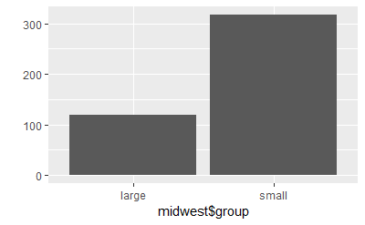

```r
library(ggplot2)
qplot(midwest$group)
```